# Load Data

```python
import pandas as pd
df_HomeData = pd.read_csv('https://storage.googleapis.com/datalynn-datasets/interview-challenge/technology/Zillow_Zestimate/HomeData.csv')
df_HomeData.head()
```

|  | HomeID | PhysicalAttrib_Rooms | PhysicalAttrib_Sqft | TaxAssessment | LastSoldPrice | LastSoldDate | Zestimate | UrbanOrRural | NearbyAvgPrice | State | SavedCount |
| --- | --- | --- | --- | --- | --- | --- | --- | --- | --- | --- | --- |
| 0 | 1 | 9 | 1919 | 292172.350222 | 284869.154909 | 2022-06-25 11:08:00 | 279068.508793 | Rural | 286694.091361 | FL | 11 |
| 1 | 2 | 3 | 2901 | 441381.806428 | 447075.261406 | 2021-09-07 11:54:00 | 438697.791461 | Urban | 428073.480255 | MS | 2 |
| 2 | 3 | 10 | 4962 | 689894.919423 | 658124.753180 | 2022-07-22 02:42:00 | 658889.224904 | Urban | 663722.141600 | IN | 3 |
| 3 | 4 | 5 | 589 | 83277.259665 | 85835.483461 | 2020-11-14 13:00:00 | 83934.848707 | Urban | 85535.571260 | OH | 10 |
| 4 | 5 | 9 | 1123 | 184636.060339 | 186501.423775 | 2019-06-30 19:08:00 | 185577.937041 | Urban | 186277.226269 | CT | 4 |

## Question 1

**Scenario**: You've been informed that some of the homes in our database may have outdated Zestimates. By analyzing the gap between `LastSoldPrice` and `Zestimate`, and considering homes sold in the last 6 months, identify homes that might have outdated Zestimates and which states have the highest percentage of such homes.

```python
import pandas as pd
from datetime import datetime, timedelta

df = df_HomeData.copy()
# Step 1: Filter for Homes Sold in Last 6 Months
six_months_ago = datetime.now() - timedelta(days=180)
df['LastSoldDate'] = pd.to_datetime(df['LastSoldDate'])
recent_sales = df[df['LastSoldDate'] > six_months_ago].copy()  # Create a copy

# Step 2: Calculate Gap between LastSoldPrice and Zestimate
recent_sales['Gap'] = abs(recent_sales['LastSoldPrice'] - recent_sales['Zestimate'])
recent_sales['RelativeGap'] = (recent_sales['Gap'] / recent_sales['LastSoldPrice']) * 100

# Step 3: Identify Outdated Zestimates
# Setting a threshold of 10% relative gap to identify outdated Zestimates
outdated_homes = recent_sales[recent_sales['RelativeGap'] > 10]

# Step 4: Analyze by State
# Count total homes and outdated homes by state
total_homes_by_state = recent_sales['State'].value_counts()
outdated_homes_by_state = outdated_homes['State'].value_counts()

# Calculate the percentage of outdated homes by state
outdated_percentage_by_state = (outdated_homes_by_state / total_homes_by_state) * 100
outdated_percentage_by_state = outdated_percentage_by_state.sort_values(ascending=False)

# Print the homes with outdated Zestimates
print("Homes with Outdated Zestimates(Head):")
print(outdated_homes.head())

# Print the states with the highest percentage of outdated Zestimates
print("State with Highest Percentage of Outdated Zestimates:")
print(outdated_percentage_by_state.head())
```

[output not shown]

```
Homes with Outdated Zestimates(Head):
State with Highest Percentage of Outdated Zestimates:
```

```
SD    15.000000
AR    13.043478
MT    12.500000
NY    10.526316
ID    10.000000
Name: State, dtype: float64
```

## Question 2

**Scenario**: For each state, determine the variability (standard deviation) of the `NearbyAvgPrice` in urban and rural areas. How does this variability compare with the overall variability of Zestimate for these homes? And how might this information be relevant in refining the Zestimate algorithm?

```python
import pandas as pd

# Step 1: Calculate standard deviation of NearbyAvgPrice by state and by UrbanOrRural
std_nearby_by_state_urban_rural = df.groupby(['State', 'UrbanOrRural'])['NearbyAvgPrice'].std().reset_index()

# Step 2: Calculate standard deviation of Zestimate by state
std_zestimate_by_state = df.groupby('State')['Zestimate'].std().reset_index()

# Step 3: Compare the variability

# Merging the two tables to make the comparison easier
merged_std = pd.merge(std_nearby_by_state_urban_rural, std_zestimate_by_state, on='State', how='inner')
merged_std.columns = ['State', 'UrbanOrRural', 'Std_NearbyAvgPrice', 'Std_Zestimate']

print("Standard Deviation of NearbyAvgPrice and Zestimate by State and Urban/Rural Classification:")
merged_std.head()
```

```
Standard Deviation of NearbyAvgPrice and Zestimate by State and Urban/Rural Classification:
```

|  | State | UrbanOrRural | Std_NearbyAvgPrice | Std_Zestimate |
| --- | --- | --- | --- | --- |
| 0 | AK | Rural | 204121.539784 | 187450.602812 |
| 1 | AK | Urban | 181260.273495 | 187450.602812 |
| 2 | AL | Rural | 201865.734506 | 191109.779755 |
| 3 | AL | Urban | 184873.176173 | 191109.779755 |
| 4 | AR | Rural | 196212.183466 | 196585.315773 |

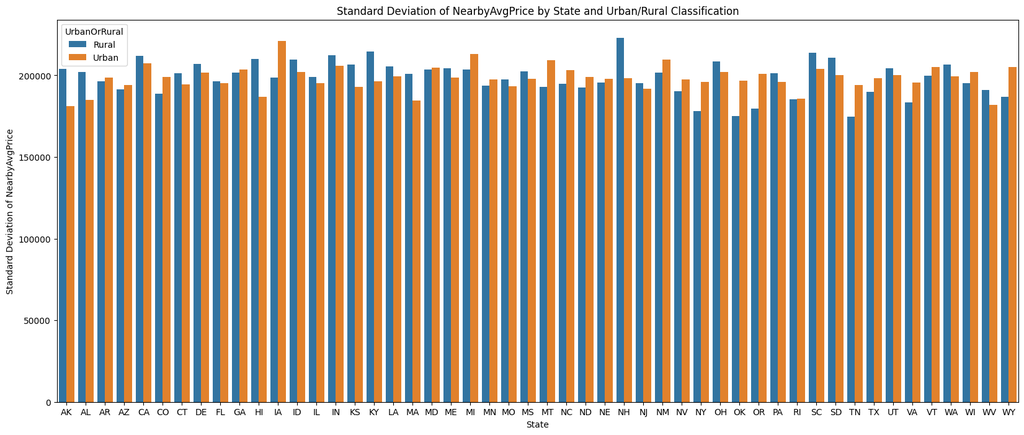

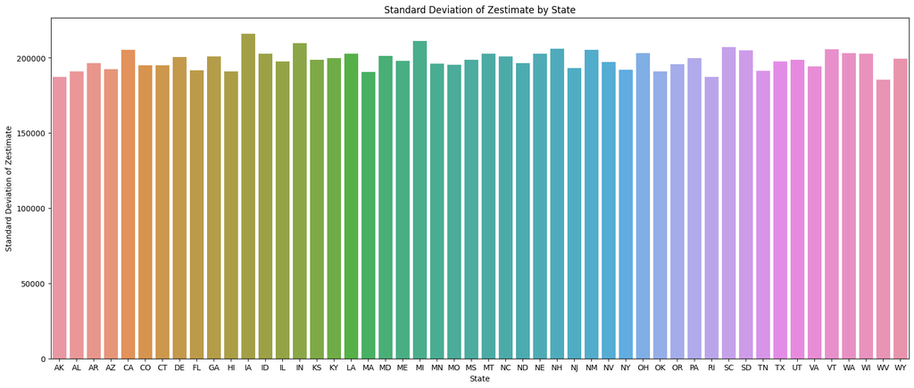

```python
import seaborn as sns
import matplotlib.pyplot as plt

# Create a bar plot for standard deviation of NearbyAvgPrice for each State, broken down by UrbanOrRural
plt.figure(figsize=(20, 8))
sns.barplot(x='State', y='Std_NearbyAvgPrice', hue='UrbanOrRural', data=merged_std)
plt.title('Standard Deviation of NearbyAvgPrice by State and Urban/Rural Classification')
plt.ylabel('Standard Deviation of NearbyAvgPrice')
plt.xlabel('State')
plt.show()

# Create a bar plot for standard deviation of Zestimate for each State
plt.figure(figsize=(20, 8))
sns.barplot(x='State', y='Std_Zestimate', data=merged_std)
plt.title('Standard Deviation of Zestimate by State')
plt.ylabel('Standard Deviation of Zestimate')
plt.xlabel('State')
plt.show()
```

**Refining Zestimate Algorithm**

- Feature Engineering: If NearbyAvgPrice shows high variability and is an important feature in the Zestimate model, you might need to engineer more specific features that capture the nuances in those regions.
- Custom Models for Different Groups: If the variability in Zestimate values is very different between urban and rural areas, you might consider developing separate models for each type of area.
- Error Analysis: High variability in Zestimate could also signal the need for a more in-depth error analysis to understand where and why the model is falling short.

## Question 3

**Scenario**: You suspect that certain physical attributes of homes might be leading to inconsistencies in Zestimate values. Develop a predictive model using relevant features to predict the `Zestimate` value. While building this model, consider techniques to handle potential overfitting, especially given the rural and urban divide in the data. Clearly indicate which feature is your target variable.  
**Target Variable**: `Zestimate`

```python
import pandas as pd
from sklearn.model_selection import train_test_split
from sklearn.preprocessing import StandardScaler, OneHotEncoder
from sklearn.compose import ColumnTransformer
from sklearn.pipeline import Pipeline
from sklearn.ensemble import RandomForestRegressor
from sklearn.metrics import mean_squared_error, mean_absolute_error
import numpy as np

# Assuming HomeData is a DataFrame containing the information
# HomeData = pd.read_csv('HomeData.csv')

# Step 1: Feature Selection
features = ['PhysicalAttrib_Rooms','PhysicalAttrib_Sqft' , 'TaxAssessment', 'UrbanOrRural', 'NearbyAvgPrice', 'State', 'SavedCount']
target = ['Zestimate']

# Step 2: Data Preprocessing
# Handling Missing Data: Drop or impute missing values if needed
# HomeData.dropna(inplace=True)  # Example to drop missing values

# Encode categorical variables and normalize numerical ones
numeric_features = ['PhysicalAttrib_Rooms','PhysicalAttrib_Sqft', 'TaxAssessment', 'NearbyAvgPrice', 'SavedCount']
categorical_features = ['UrbanOrRural', 'State']

numeric_transformer = StandardScaler()
categorical_transformer = OneHotEncoder(handle_unknown='ignore')

preprocessor = ColumnTransformer(
    transformers=[
        ('num', numeric_transformer, numeric_features),
        ('cat', categorical_transformer, categorical_features)])

# Step 3: Model Selection
model = RandomForestRegressor(n_estimators=100, random_state=0)

# Combining preprocessor and the model into a single pipeline
pipeline = Pipeline(steps=[('preprocessor', preprocessor),
                           ('model', model)
                           ])

# Step 4: Train-Test Split
X = df[features]
y = df[target]
X_train, X_test, y_train, y_test = train_test_split(X, y, test_size=0.2, random_state=0)

# Step 5: Model Training
pipeline.fit(X_train, y_train.values.ravel())

# Step 6: Model Evaluation
y_pred = pipeline.predict(X_test)
rmse = np.sqrt(mean_squared_error(y_test, y_pred))
mae = mean_absolute_error(y_test, y_pred)

print(f"Root Mean Square Error: {rmse}")
print(f"Mean Absolute Error: {mae}")
```

```
Root Mean Square Error: 18402.492316189055
Mean Absolute Error: 11874.612996187665
```

## Question 4

**Scenario**: The number of times a home is saved (`SavedCount`) can be an indirect indicator of its popularity or demand. Suppose there's a new feature in the pipeline that would allow users to get instant notifications for homes with high `SavedCount`. How would you leverage the current data to determine the threshold for "high `SavedCount`"? Also, discuss potential implications on the Zestimate value for homes that get flagged with this feature.

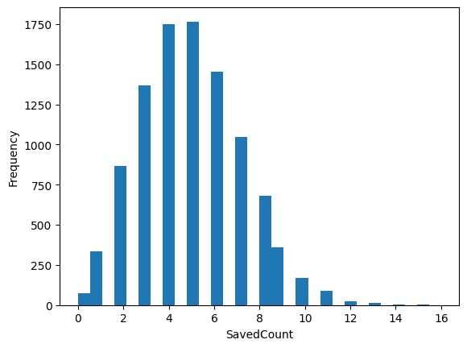

```python
# Descriptive Statistics: The first step could be to look at the basic statistics of the SavedCount variable, including the mean, median, and standard deviation.
mean_saved_count = df['SavedCount'].mean()
median_saved_count = df['SavedCount'].median()
std_saved_count = df['SavedCount'].std()

# Percentile Analysis: Analyzing the percentile distribution can provide more robust cut-off points for "high SavedCount".
# For instance, homes in the top 5% or 10% could be considered as having a high SavedCount.
percentile_90 = np.percentile(df['SavedCount'], 90)
percentile_95 = np.percentile(df['SavedCount'], 95)

# Visualizations: Plotting histograms or boxplots could also provide a visual sense of the distribution of SavedCount.
plt.hist(df['SavedCount'], bins=30)
plt.xlabel('SavedCount')
plt.ylabel('Frequency')
plt.show()
```

**Implications on Zestimate**

- Increased Visibility: Homes flagged as high SavedCount could receive more views, which may potentially translate into more demand and thus a higher Zestimate.
- Positive Feedback Loop: A higher Zestimate could make a home appear more desirable, increasing its SavedCount and thereby creating a positive feedback loop.
- Data Skewness: If SavedCount is a feature used in Zestimate calculations, the new feature may lead to skewed estimations for homes that are flagged.